# R Notebook

Hengyang Lin hl3116

## In this report, I will focus on what kind of people would gain happiness from a specific source. The sources of happiness could be approximately substituted by Topics when refer to happiness. And then I will explore the structure of the population whose people get happy from a specific sourece.

## The idea is simple: First we cluster the data to gain topics as substitutions of sources of happiness. Then we explore the population feature of each cluster.

# Step 0: Getting Data

Load libraries.

```r
packages.used <- c("tm", "wordcloud", "RColorBrewer",
                "dplyr", "tydytext","topicmodels","qdap")
# check packages that need to be installed.
packages.needed <- setdiff(packages.used,
                        intersect(installed.packages()[,1],
                                  packages.used))
# install additional packages
if(length(packages.needed)>0){
  install.packages(packages.needed, dependencies = TRUE,
                   repos='http://cran.us.r-project.org')
}
library(tidyverse)
library(tidytext)
library(DT)
library(scales)
library(wordcloud2)
library(gridExtra)
library(ngram)
library(shiny)
library(ggplot2)
library(dplyr)
library(wordcloud)
library(RColorBrewer)
library(tm)
library(topicmodels)
library(qdap)
```

Load the processed data & demographic data.

```r
urlfile<-'https://raw.githubusercontent.com/rit-public/HappyDB/master/happydb/data/cleaned_hm.csv'
hm.data <- read_csv(urlfile) #load the raw data

corpus <- VCorpus(VectorSource(hm.data$cleaned_hm))%>%
  tm_map(content_transformer(tolower))%>%
  tm_map(removePunctuation)%>%
  tm_map(removeNumbers)%>%
  tm_map(removeWords, character(0))%>%
  tm_map(stripWhitespace) #clean data, remove punctuation, numbers,etc

stemmed <- tm_map(corpus, stemDocument) %>%
  tidy() %>%
  select(text)

dict <- tidy(corpus) %>%
  select(text) %>%
  unnest_tokens(dictionary, text)


data("stop_words")

word <- c("happy","ago","yesterday","lot","today","months","month",
                 "happier","happiest","last","week","past","day","time","spent","celebrated","fun","moment")

stop_words <- stop_words %>%
  bind_rows(mutate(tibble(word), lexicon = "updated")) #remove stopwords

completed <- stemmed %>%
  mutate(id = row_number()) %>%
  unnest_tokens(stems, text) %>%
  bind_cols(dict) %>%
  anti_join(stop_words, by = c("dictionary" = "word"))

completed <- completed %>%
  group_by(stems) %>%
  count(dictionary) %>%
  mutate(word = dictionary[which.max(n)]) %>%
  ungroup() %>%
  select(stems, word) %>%
  distinct() %>%
  right_join(completed) %>%
  select(-stems)

completed <- completed %>%
  group_by(id) %>%
  summarise(text = str_c(word, collapse = " ")) %>%
  ungroup()

hm.data <- hm.data %>%
  mutate(id = row_number()) %>%
  inner_join(completed)


write_csv(hm.data, "../output/processed_moments.csv")


urlfile<-'https://raw.githubusercontent.com/rit-public/HappyDB/master/happydb/data/demographic.csv'
demo.data <- read_csv(urlfile)
```

Merge the text data and demographic data.

```r
hm.data <- hm.data %>%
  inner_join(demo.data, by = "wid") %>%
  select(wid,
         original_hm,
         gender,
         marital,
         parenthood,
         reflection_period,
         age,
         country,
         ground_truth_category,
         text) %>%
  mutate(count = sapply(hm.data$text, wordcount)) %>%
  filter(gender %in% c("m", "f")) %>%
  filter(marital %in% c("single", "married")) %>%
  filter(parenthood %in% c("n", "y")) %>%
  filter(reflection_period %in% c("24h", "3m")) %>%
  mutate(reflection_period = fct_recode(reflection_period,
                                        months_3 = "3m", hours_24 = "24h"))

hm.data <- na.omit(hm.data)
```

# Step 1: Data Overview

Our data can be devided into different groups by different variable. Let’s have a look at the whole data.

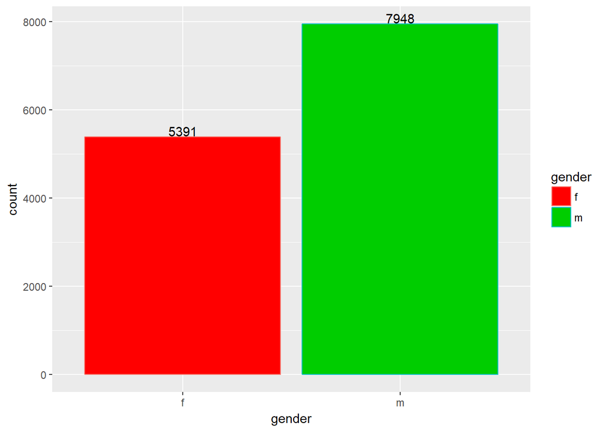

```r
#Female vs Male
ggplot(data = hm.data) +
  geom_bar(mapping = aes(x = gender, color = gender), fill = 2:3) +
  geom_text(aes(x = gender, label = ..count..), stat = "count", vjust = -0.1)
```

We have more male observations than female.

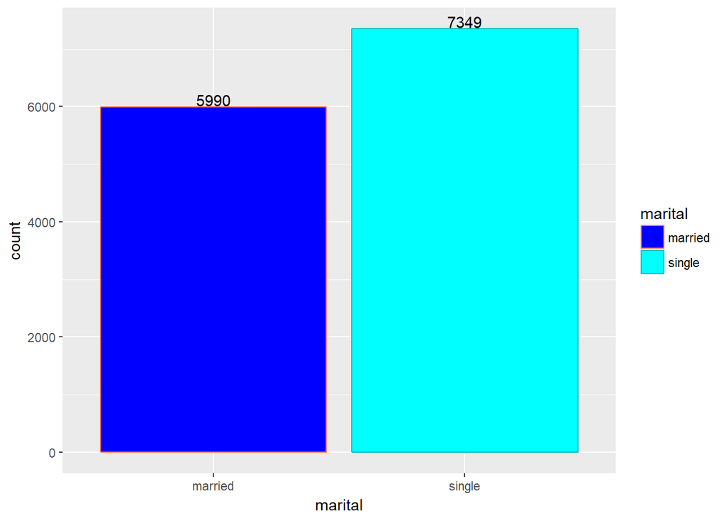

```r
#Maried vs Single
ggplot(data = hm.data) +
  geom_bar(mapping = aes(x = marital, color = marital), fill = 4:5) +
  geom_text(aes(x = marital, label = ..count..), stat = "count", vjust = -0.1)
```

We have more single people in the sample than married.

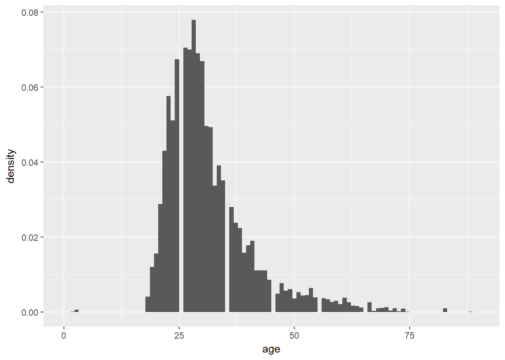

```r
#Age distribution
age <- as.numeric(hm.data$age)
hm.data <- hm.data[!is.na(age),]
ggplot(data = hm.data, aes(x = as.numeric(age), y = ..density..)) +
  geom_histogram(bins = 100) +
  scale_x_continuous(limits = c(0,90))+
  xlab("age")
```

```r
#Country distribution
hm.data.split_country <- hm.data %>% group_by(country) %>%
  summarise(population_count = length(country))
ind <- order(hm.data.split_country$population_count, decreasing = TRUE)
head(hm.data.split_country[ind,],10)
```

```
## # A tibble: 10 x 2
##    country population_count
##    <chr>              <int>
##  1 USA                 9787
##  2 IND                 2939
##  3 CAN                   69
##  4 VEN                   68
##  5 GBR                   52
##  6 PHL                   36
##  7 VNM                   28
##  8 MEX                   21
##  9 BRA                   19
## 10 DEU                   15
```

We have listed 10 countries with most people in this sample. We can learn that most people in this sample are from USA and India when people from USA constitute the majority. All other countries such as Canada and Venezuela contribute very little to this sample.

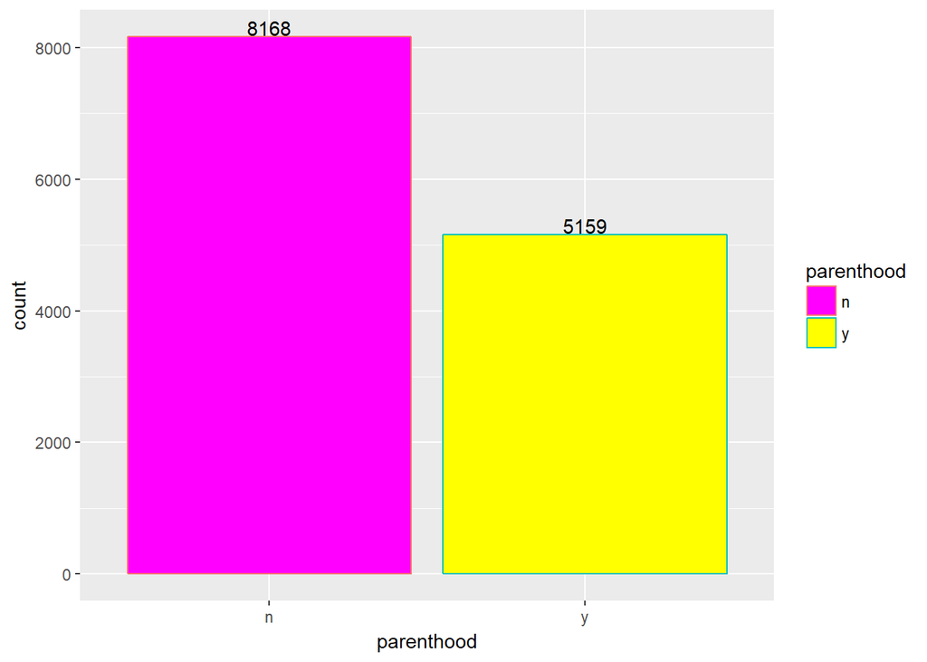

```r
#Parenthood: Yes or No
ggplot(data = hm.data) +
  geom_bar(mapping = aes(x = parenthood, color = parenthood), fill = 6:7) +
  geom_text(aes(x = parenthood, label = ..count..), stat = "count", vjust = -0.1)
```

We can see from the graph that there are more people without children in this sample.

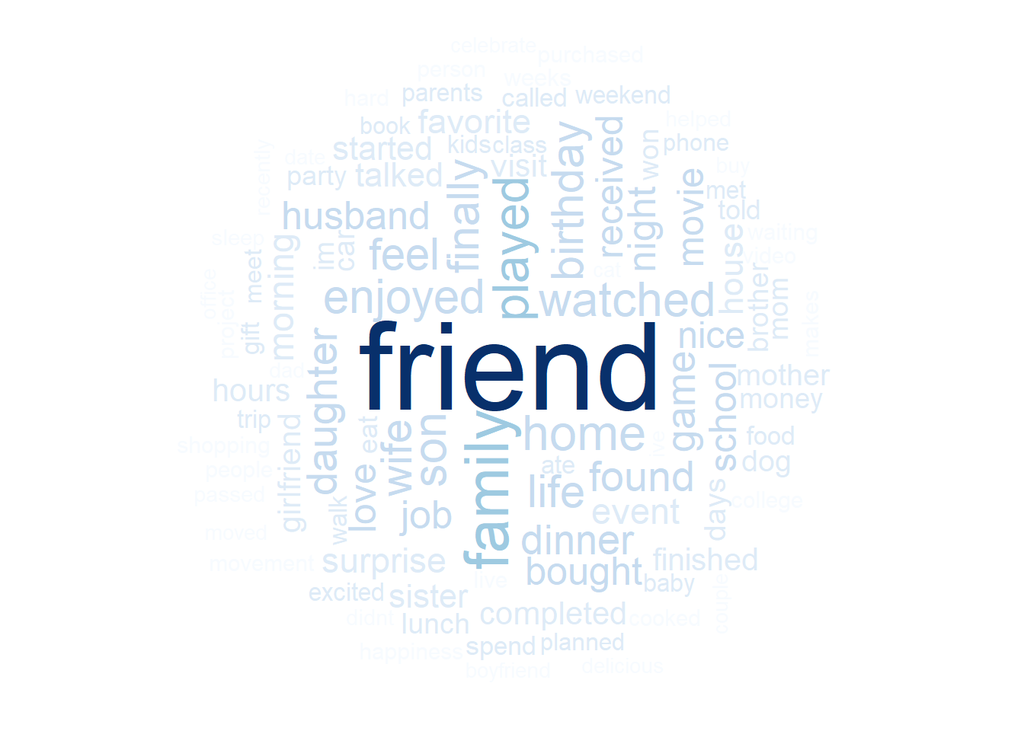

```r
#Overall Wordcloud
alltext <- hm.data$text
text.df <- data_frame(obs = 1:length(alltext), text = alltext)
text.tidy <- text.df %>%
  unnest_tokens(word, text) #tokenization, seperate sentence to word

word_count <- text.tidy %>%
  count(word, sort = TRUE) #get a dataframe with count for each word

wordcloud(word_count$word, word_count$n,
          scale=c(5,0.5),
          max.words=100,
          min.freq=1,
          random.order=FALSE,
          rot.per=0.3,
          use.r.layout=T,
          random.color=FALSE,
          colors=brewer.pal(9,"Blues"))
```

This is the overall word cloud for the discription of happy moments. As we can see, “friend” is the most frequent word when people talk about happiness, followed with “family”, “watched”, etc. It seems that people get happy from doing something, since we have “watched” and “played” for frequent word, and also get happy from other people, such as “friend” and “family”.

# Step 2: Topic Model

I would like to perform a topic model on this sample, because topic model helps us for understanding the main source of our happiness through clustering.

```r
docs <- Corpus(VectorSource(hm.data$text))
dtm <- DocumentTermMatrix(docs)
rownames(dtm) <- paste(hm.data$gender, hm.data$marital,
                       hm.data$parenthood, hm.data$age, sep="_")
rowTotals <- apply(dtm , 1, sum) #Find the sum of words in each Document

dtm  <- dtm[rowTotals> 0, ]
hm.data <- hm.data[rowTotals>0, ]

#Run LDA

#Set parameters for Gibbs sampling
burnin <- 4000
iter <- 2000
thin <- 500
seed <-list(2736,47,193,658,1029)
nstart <- 5
best <- TRUE

#Number of topics
k <- 10

#Run LDA using Gibbs sampling
ldaOut <-LDA(dtm, k, method="Gibbs", control=list(nstart=nstart,
                                                 seed = seed, best=best,
                                                 burnin = burnin, iter = iter,
                                                 thin=thin))

#write out results
#docs to topics
ldaOut.topics <- as.matrix(topics(ldaOut)) #result of clustering
table(c(1:k, ldaOut.topics))
```

```
##
##    1    2    3    4    5    6    7    8    9   10
## 2174 1705 1290 1715 1068 1287  927 1071 1159  939
```

```r
write.csv(ldaOut.topics,file=paste("../output/LDAGibbs",k,"DocsToTopics.csv"))

#top 20 terms in each topic
ldaOut.terms <- as.matrix(terms(ldaOut,20))#top 20 terms in each topic
write.csv(ldaOut.terms,file=paste("../output/LDAGibbs",k,"TopicsToTerms.csv"))

#probabilities associated with each topic assignment
topicProbabilities <- as.data.frame(ldaOut@gamma)
write.csv(topicProbabilities,file=paste("../output/LDAGibbs",k,"TopicProbabilities.csv"))

ldaOut.terms
```

```
##       Topic 1     Topic 2     Topic 3      Topic 4     Topic 5
##  [1,] "home"      "family"    "feel"       "job"       "life"
##  [2,] "son"       "birthday"  "love"       "received"  "event"
##  [3,] "sister"    "surprise"  "morning"    "money"     "talked"
##  [4,] "visit"     "brother"   "night"      "weeks"     "trip"
##  [5,] "lunch"     "party"     "makes"      "project"   "spend"
##  [6,] "mother"    "completed" "happiness"  "promotion" "planned"
##  [7,] "wife"      "gift"      "people"     "pay"       "weekend"
##  [8,] "meet"      "phone"     "live"       "company"   "parents"
##  [9,] "baby"      "person"    "sleep"      "recently"  "exam"
## [10,] "father"    "movement"  "share"      "helped"    "successfully"
## [11,] "learned"   "dad"       "smile"      "hit"       "proud"
## [12,] "birth"     "celebrate" "woke"       "called"    "office"
## [13,] "cooked"    "date"      "children"   "goal"      "remember"
## [14,] "travel"    "waiting"   "wonderful"  "managed"   "free"
```

[output cut: 27 more lines]

Clearly we can find clues in the top 20 terms of each topics:

For topic 1, the terms strongly imply that these observations are clustered by family or relatives, which means one of the sources of happiness. So we assign hashtag “family” to Topic 1.

For topic 2, the terms involve “birthday”, “party”,“marriage”,“attended”,etc, which are mostly about social activities. So we assign hashtag “social activity” to Topic 2.

For topic 3, the terms involve “feel”, “love”, which are something about mood, as well as “morning”, “night”, “joy”,“smile”,“sleep”,“wake”, which are about good life. So we assign hashtag “good mood and life” to Topic 3.

For topic 4, the terms strongly imply that these observations are clustered by career and money, which means one of the sources of happiness. So we assign hashtag “career” to Topic 4.

For topic 5, the main topic is quite blurred. It may involve being with others, inferred from “talked”,“spend”,“trip”,“parents”,etc, also might be about success, which is deduced from “successfullt”,“didnt”,“havent”. So we assign “accompany and success” to Topic 5.

For topic 6, it’s very obvious that we could assign “food” to Topic 6.

For topic 7, it’s very obvious that we could assign “education” to Topic 7.

For topic 8, it’s very obvious that we could assign “shopping” to Topic 8.

For topic 9, the terms are about relaxing or vacation, so we could assign “vacation” to Topic 9.

For topic 10, it’s very obvious that we could assign “sport” to Topic 10.

# Step 3: Analysis on each cluster

```r
topic_tag <- c("family","social activity","good mood and life","career","accompany and success",
               "food","education","shopping","vacation","sport")

#seperate the data into different clusters
ind.df <- read.csv("../output/LDAGibbs 10 DocsToTopics.csv")
hm_data <- data.frame(hm.data, topic = as.integer(ind.df$V1))
```

## a). Let’s have a look about how gender would change among different clusters.

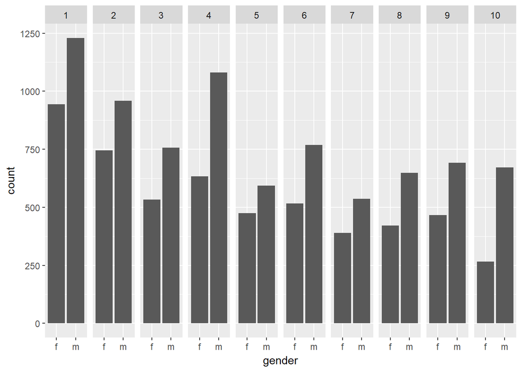

```r
ggplot(hm_data) +
  geom_bar(mapping = aes(x = gender)) +
  facet_grid(.~topic,scales = "fixed")
```

As we can from the figure, the gender odd between genders basically keeps stable in clusters, except the cluster of topic 10 “sport”.

It is very obvious that in cluster 10 with hash-tag “sport”, the proportion of female people is significantly lower than it in other clusters. This conforms to our daily impression that male people would be more possibly getting happy from sport.

## b).

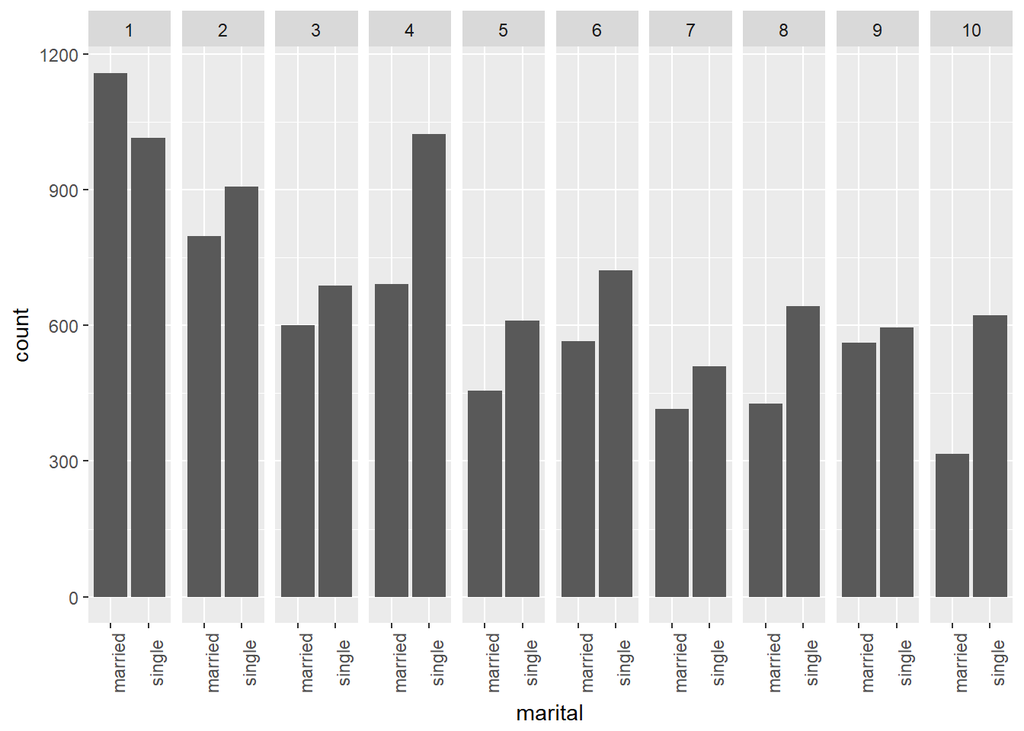

```r
ggplot(hm_data) +
  geom_bar(mapping = aes(x = marital)) +
  facet_grid(.~topic,scales = "fixed") +
  theme(axis.text.x = element_text(angle = 90, hjust = 0.5))
```

This graph is very interesting. The cluster 1 has the biggest odd for married via single. Actually, cluster 1 is the only cluster that whose married people exceed single people.

We know that since the topic of cluster 1 is “family”, maybe we do verify that if one person gains happiness from family, he would be more likely to be a married person.

The odd for married via single is quite small in both cluster 4 and cluster 10. The topic of cluster 4 is “career”, which indicates that single person may tend to acquire happiness from favorably career.

## c).

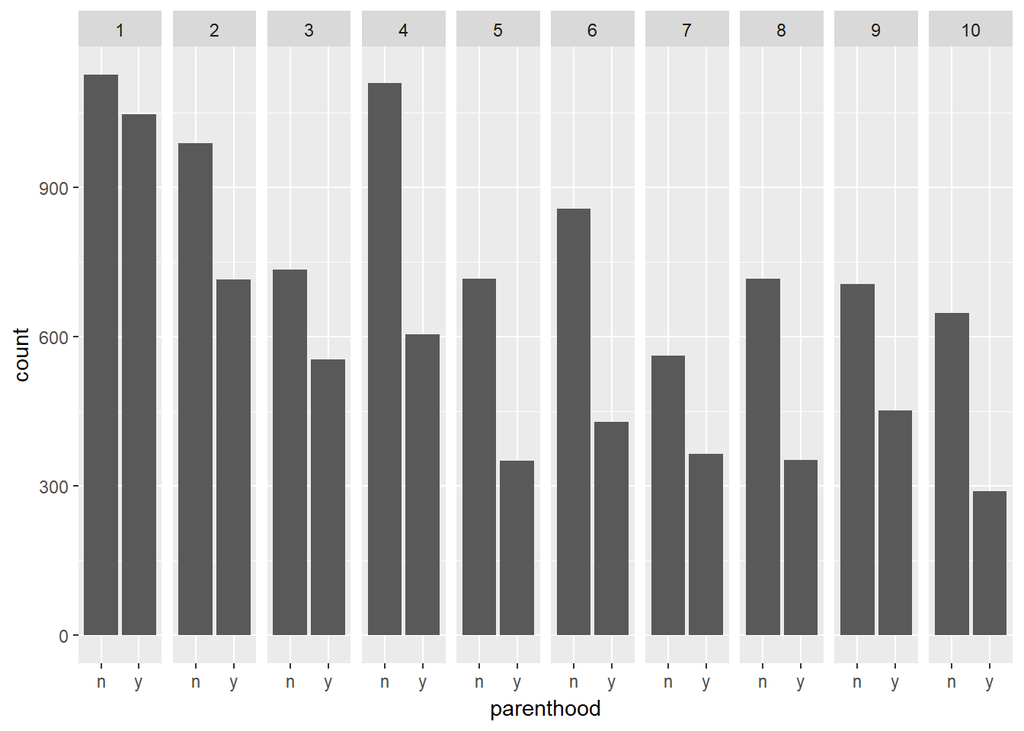

```r
ggplot(hm_data) +
  geom_bar(mapping = aes(x = parenthood)) +
  facet_grid(.~topic,scales = "fixed")
```

##d).

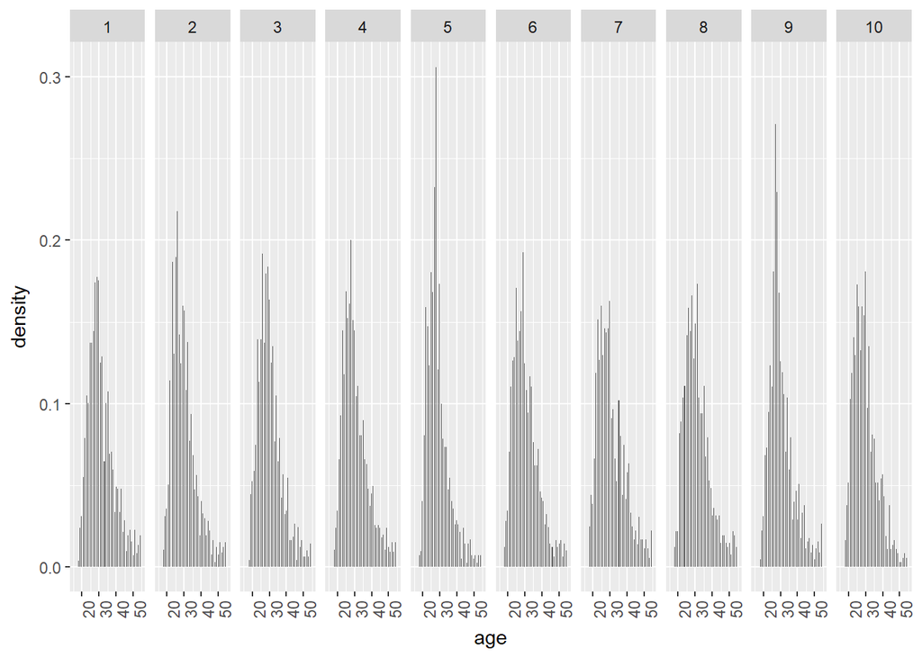

```r
#Age distribution
ggplot(data = hm_data, aes(x = as.numeric(age), y = ..density..)) +
  geom_histogram(bins = 100) +
  scale_x_continuous(limits = c(15,55))+
  xlab("age") +
  theme(axis.text.x = element_text(angle = 90, hjust = 0.5)) +
  facet_grid(.~topic,scales = "fixed")
```